# SPRING2023 – Summerschool Python Remote für Ingenieurinnen

## Aufgabensammlung Teil 2 (für Dienstag 2023-09-27)

Dieses Notebook enthält Anregungen für Übungsaufgaben. Hinweise zur Lösung können dem Kursmaterial (Folien), dem Notebook 00_demo und den aufgabenspezifischen Tipps entnommen werden.

**Empfehlung**: Musterlösung nicht kopieren, sondern selber abschreiben (schärft den Blick fürs Detail).

```python
import numpy as np
import matplotlib.pyplot as plt
from IPython.display import display
%matplotlib inline
```

### Aufgabe 1

Informieren Sie sich (durch Recherche, Ausprobieren oder den `?` Operator hier im Jupyter Notebook) über die drei Funktionen `np.linspace`, `np.logspace`, `np.arange` und beschreiben Sie Gemeinsamkeiten und Unterschiede in eigenen Worten (schriftlich, in Stichpunkten).

**→ Tipps ▼**

- Führen Sie folgende Anweisung in einer leeren Zelle aus: `np.linspace?`

**→ Musterlösung ▼**

```python
# Hier bitte Lösung einfügen
```

### Aufgabe 2

Gegeben sei `x1 = np.linspace(10, 20)`. Erzeugen Sie ein äquvalentes Array `x2` mit Hilfe von `np.arange`.

**→ Tipps ▼**

- Berechnen Sie die Schrittweite in x1 - Beachten Sie dass, in `arange` der Endwert als *exklusive* betrachtet wird.

**→ Musterlösung ▼**

```python dx = x1[1] - x1[0] x2 = np.arange(10, 20 + dx, dx) ```

```python
# Hier bitte Lösung einfügen
```

### Aufgabe 3

Gegeben sei `x3 = np.arange(10, 20, 0.25)`. Erzeugen Sie ein äquvalentes Array `x4` mit Hilfe von `np.linspace`.

**→ Tipps ▼**

- Bestimmen Sie Anfangs- und Endwert, sowie die Länge von `x3`

**→ Musterlösung ▼**

```python x4 = np.linspace(x3[0], x3[-1], len(x3)) ```

```python
# Hier bitte Lösung einfügen
```

### Aufgabe 4

Gegeben sei `x5 = np.logspace(-2, 1, 20)`. Erzeugen Sie ein äquvalentes Array `x4` mit Hilfe von `np.linspace`.

**→ Tipps ▼**

- Überlegen bzw. recherchieren Sie wodurch sich die logspace und linspace unterscheiden. - Führen Sie eine geeignete mathematische Transformation von $x5$ durch.

**→ Musterlösung ▼**

```python x6 = 10**np.linspace(np.log10(x5[0]), np.log10(x5[-1]), 20) ##: # alternativ: x6 = 10**np.linspace(-2, 1, 20) ##: ```

```python
# Hier bitte Lösung einfügen
```

### Aufgabe 5

Stellen Sie die Funktionen $y_1=\sin(2\pi x)$, $y_2=\sin(2\pi x^2)$ im Intervall $x \in [-1, 2]$ grafisch dar.

**→ Tipps ▼**

`np.linspace?`, `np.pi`, `np.sin`, `plt.plot`

**→ Musterlösung ▼**

```python x = np.linspace(-1, 2, 300) y1 = np.sin(2*np.pi*x) y2 = np.sin(2*np.pi*x**2) plt.plot(x, y1) plt.plot(x, y2) ```

```python
# Hier bitte Lösung einfügen
```

Denkanstöße:

- Wie können Sie die "Auflösung" der Funktionsauswertung verändern (Tipp: Parametrierung von `linspace` anpassen)? Welche Auswirkung haben sehr große und sehr keine Längen des Arrays für die $x$-Werte?

### Aufgabe 6

Reproduzieren Sie folgendens Bild.

[figure not shown]

Hinweis: Suchen Sie unter https://matplotlib.org/gallery/index.html nach einem passenden Beispiel (relativ weit unten)

**→ Tipps ▼**

Suchen Sie nach "Parametric Curve"

**→ Musterlösung ▼**

Der didaktische Zweck dieser Aufgabe ist es, die [umfangreiche Beispielgallerie](https://matplotlib.org/gallery/index.html) zur Kenntnis zu nehmen. Deswegen wird hier keine Musterlösung angegeben.

```python
# Hier bitte Lösung einfügen
```

Denkanstöße:

- Wie muss der Code verändert werden, damit die Schraubenlinie einer 15mm [M12-Schraube](https://de.wikipedia.org/wiki/Metrisches_ISO-Gewinde) dargestellt wird?

Zeichnen Sie einen Kreis mir Radius $r=2.5$, der auch aussieht wie ein Kreis, d. h. nicht Eigenschaften des Bildschirms verzerrt wird.

**→ Tipps ▼**

- `np.sin()`, `np.cos()` - `plt.axis("equal")`

**→ Musterlösung ▼**

```python N = 400 r = 2.5 t = np.linspace(0, 2*np.pi, N) x = r*np.cos(t) y = r*np.sin(t) plt.plot(x, y) plt.axis("equal") ```

### Aufgabe 8

[figure not shown]

Als einfaches Modell eines RL-Gliedes (mit einer messbedingten Zeitverzögerung) ist die komplexwertige Funktion

$$G(j\omega) = \dfrac{1}{1 + j\omega} e^{-j\omega}$$

gegeben.

Stellen Sie den Frequenzgang (auch "Ortskurve)") dieser Übertragungsfunktion für $\omega\in (0, \inf) $ in der komplexen Ebene dar.

Ziel-Ergebnis:

[figure not shown]

**→ Tipps ▼**

- Nähern Sie $0$ und $\infty$ durch geeignete endliche Werte - `1j` ist die imaginäre Einheit (komplex Zahl) - `np.logspace?`: logarithmisch skalierter 1D-Array - `np.exp(...)` Exponentialfunktion

**→ Musterlösung ▼**

```python omega = np.logspace(-2, 2, 300) # 300 Werte zwischen 0.01 und 100 jw = 1j*omega G = 1/(1+ jw) * np.exp(-jw) plt.plot(np.real(G), np.imag(G)) # Optional: Gitternetz plt.grid() ```

```python
# Hier bitte Lösung einfügen
```

**Denkanstöße:**

- Wie können Sie die imaginäre und die reelle Achse als Schwarze linien einzeichnen?
- Warum ist `np.logspace` hier sinnvoller als `np.linspace()`? (→Für niedrige Auflösung ausprobieren!)
- Wie ließe sich das Bode-Diagramm (Betrag und Phase, jeweils in Abängigkeit von $\omega$ darstellen)? (Hilfreich: [Begleitmaterial zu Kap. 5 im Buch "Python für Ingenieure für Dummies"](https://nbviewer.org/github/python-fuer-ingenieure/material/blob/main/notebooks/kapitel_05_mathe/mathe.ipynb))

### Aufgabe 9

Erzeugen Sie 1000 zufällige Werte die einer Standard-Normalverteilung genügen ($\mu=0$, $\sigma=1$). Plotten Sie das "Wahrscheinlickeitsdichte-Histogramm" für diese Verteilung in halb durchsichtigem Blau und den theoretisch erwarteten Verlauf der Kurve in Organge mit Linienstärke 2.

Ziel-Ergebnis:

[figure not shown]

**→ Tipps ▼**

- `np.random.normal?` - `plt.hist?` - Gauß-Kurve (für gegebene `xx`-Werte): `yy = 1/(np.sqrt(2*np.pi)*sigma)*np.exp(-(xx-mu)**2/(2*sigma**2))`

**→ Musterlösung ▼**

```python # Normalverteilte Zufallszahlen erzeugen data = np.random.normal(0, 1, 1000) # Histogramm berechnen hist, bins = np.histogram(data, bins=50) # Plot the histogram plt.hist(data, bins=50, density=True, alpha=0.5) mu = 0 sigma = 1 xx = np.linspace(-4, 4) yy = 1/(np.sqrt(2*np.pi)*sigma)*np.exp(-(xx-mu)**2/(2*sigma**2)) plt.plot(xx, yy, linewidth=2, color="tab:orange") ```

```python
# Hier bitte Lösung einfügen
```

**Denkanstöße:**

- Wie können Sie die orangene Linie "hinter" bzw. "unter" das Histogram legen?
- Wie können Sie Mittelwert und Varianz sowohl vom Histogram als auch von der Kurve verändern?

## Aufgabe 10

Gegeben sei folgender Quelltext, welcher eine Kurvenschar erzeugt:

```
N = 1000
xx = np.linspace(0, 10, N)

M = 10
for s in np.linspace(1, 2, M):
    yy = (1-s)*np.sin(xx**2)*np.exp(-s/3*xx)

    plt.plot(xx, yy, color="tab:blue")
```

Verändern Sie den Quelltext mit Hilfe der Funktion `zip` und dem Schlüsselwort-Argument`alpha=...` (für die Funktion `plt.plot(...)`) so, dass die Folgende Grafik entsteht:

[figure not shown]

**→ Tipps ▼**

- Recherchieren Sie über die `zip`-Funktion und nutzen Sie das Beispiel: `list(zip([10, 20, 30], "abc"))` bzw. eigene Abwandlungen davon für Ihr verständnis - Nutzen Sie Syntax zum Entpacken von Tupeln (Bsp: `x, y = (20, "b")`) direkt im Schleifenkopf

**→ Musterlösung ▼**

```python N = 1000 xx = np.linspace(0, 10, N) M = 10 for s, a in zip(np.linspace(1, 2, M), np.linspace(0.1, 1, M)): yy = (1-s)*np.sin(xx**2)*np.exp(-s/3*xx) plt.plot(xx, yy, color="tab:blue", alpha=a) ```

```python
# Hier bitte Lösung einfügen
```

**Denkanstöße:**

- Wie können Sie die einzelnen Kurven in verschiedenen Graustufen darstellen?

## Aufgabe 11

Erzeugen Sie für $n \in \{20, 100, 300\}$ je ein zufälliges $n \times n$-Array und stellen Sie es mit Hilfe von `imshow` grafisch dar. Alle drei Bilder sollen nebeneinander liegen.

Ziel:

[figure not shown]

**→ Tipps ▼**

- `fig, (ax0, ax1, ax2) = plt.subplots(...)` - (`fig` wird hier zwar zurückgegeben, aber nicht benötigt) - `ax.imshow(...)`

**→ Musterlösung ▼**

```python fig, (ax0, ax1, ax2) = plt.subplots(1, 3, figsize=(9, 3)) n=20 img0 = np.random.rand(n, n) n=100 img1 = np.random.rand(n, n) n=300 img2 = np.random.rand(n, n) ax0.imshow(img0) ax1.imshow(img1) ax2.imshow(img2) ```

```python
# Hier bitte Lösung einfügen
```

**Denkanstöße:**

- (Bezogen auf die Musterlösung): Wie lässt sich mit Hilfe einer Schleife erreichen, dass weniger Code-Duplikation auftritt (Bessere Beachtung des **DRY**-Prinzips: Don't Repeat Yourself!)
- Füllen Sie den linken oberen Quadranten jeweils vor dem Plotten jeweils mit dem Wert `0`
- Wählen Sie unter von https://matplotlib.org/stable/users/explain/colors/colormaps.html eine andere "colormap" aus

### Aufgabe 12

Gegeben ist ein mechanisches System bestehend aus zwei visko-elastisch gekoppelten Körpern:

[figure not shown]

Die Bewegungsgleichungen für dieses System lauten:

$$ \begin{align} %\label{eq_} m_1 \ddot q_1 + d_1 (\dot q_1 - \dot q_2) + c_1 (q_1 - q_2) &= F\\ m_2 \ddot q_2 - d_1 (\dot q_1 - \dot q_2) - c_1 (q_1 - q_2) &= 0. \end{align} $$

Simulieren Sie (durch Anpassung des Notebooks Simulation_dynamischer_Systeme.ipynb) die Bewegung des Systems und visualisieren Sie die Zeitverläufe von $q_1(t), q_2(t)$ für $t \in [0s, 7s]$. Es gelten folgende Annahmen:

- Das System befindet sich am Anfang in Ruhe bei $q_1(t) = q_2(t) = 0$
- Der Verlauf der äußeren Kraft $F$ ist $F = \cases{\sin(\pi\cdot t)\enspace \text{für} ~t \in [0s, 2s],\\ 0 \hspace{16mm} \text{sonst}}$
- Die Paramter haben folgende (normierte) Werte: $m_1 = 1$, $m_2 = 0.5$, $c_1 = 10$, $d_1 = 0.3$

**→ Tipps ▼**

- Lösen Sie (ggf. auf Papier) die Bewegungsgleichungen nach den Beschleunigungen auf - Nutzen Sie $\mathbf x = (x_1, x_2, x_3, x_4)^T = (q_1, q_2, \dot q_1, \dot q_2)^T$ als Definition des Zustandsvektors - Schreiben Sie eine Funktion `rhs(t, xx)`, welche zu einem gegebenen Zeitpunkt `t` für einen gegebenen Zustandsvektor $\mathbf x=$`xx` die zugehörige Zeitableitung des Zustandsvektors $\ddot {\mathbf{x}}=(\dot x_1, \dot x_2, \dot x_3, \dot x_4)^T = (\dot q_1, \dot q_2, \ddot q_1, \ddot q_2)^T$=`xxdot` ausrechnet und zurückgibt (`return`). - Nutzen Sie `solve_ivp` wie im Beispiel Notebook.

**→ Musterlösung ▼**

```python from scipy.integrate import solve_ivp import matplotlib.pyplot as plt # Parameter festlegen: m1 = 1 m2 = 0.5 c1 = 10 d1 = 0.3 # Definition der rechten Seite (f) der Zustands-DGL def rhs(t, xx): """ :param t: Auswertezeitpunkt (wichtig für F(t)) :param xx: Zustandsvektor :returns: time derivative of the state vector (as 1D-array) """ q1, q2, q1dot, q2dot = xx # Boolsche Werte können in numerischen Rechnungen # als 1 (True) oder 0 (False) verwendet werden F_condition = t<2 F = np.sin(np.pi*t)*F_condition # Geschwindigkeiten (definitorische Gleichungen) x1dot = q1dot x2dot = q2dot # Beschleunigungen (umgestellte Bewegungsgleichungen) x3dot = (F - d1*(q1dot - q2dot) - c1*(q1 - q2))/m1 x4dot = (d1*(q1dot - q2dot) + c1*(q1 - q2))/m2 # Zeitableitung des Zustandsvektors xxdot = np.array([x1dot, x2dot, x3dot, x4dot]) return xxdot # Anfangszustand xx0 = [0, 0, 0, 0] # Auswertezeitpunkte (20s) tt = np.linspace(0, 7, 1000) res = solve_ivp(rhs, (tt[0], tt[-1]), xx0, t_eval=tt, max_step=0.1) # Erinnerung: res.y ist ein 2D-Array des Simulationsergebnisses # (Zeilen: Zustandskomponenten; Spalten: Zeitpunkte) plt.plot(tt, res.y[0, :], label="$q_1$(t)") plt.plot(tt, res.y[1, :], label="$q_2$(t)") plt.legend() ```

```python
# Hier bitte Lösung einfügen
```

**Denkanstöße:**

- Was passiert bei einer zeitlich konstanten Kraft $F >0$?
- Wie können Sie (in einer separaten Abbildung) die beiden Geschwindigkeiten und die Relativgeschwindigkeit der beiden Wagen visualisieren?
- Wie können Sie die an das System übertragene Leistung und die im System gespeicherte Energie (potentiell und kinetisch) berechnen und visualisieren?

### Aufgabe 13

Der folgende Code repräsentiert mit der Funktion $\mathbf f$ ≙`f` die Temperaturverteilung auf der Wärmebildaufnahme eines Werkstücks. Die Funktion bildet 2D-Vektoren $\left(\begin{smallmatrix} x\\ y \end{smallmatrix} \right) \in \mathbb{R}^2$ auf einen 1D Temperaturwert $z \in \mathbb{R}$ ab und ist im Bereich $-1 \leq x, y \leq 1$ grafisch dargestellt.

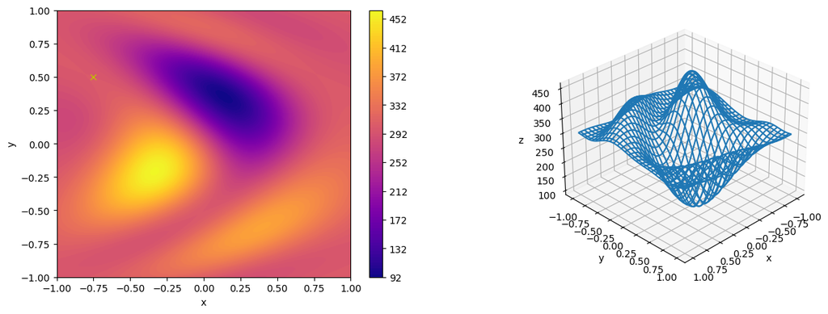

```python
def f(xx):
    """
    Funktion der Temperaturverteilung (ersetzt Messdaten)
    """

    hull = -30*np.exp(-(xx[0]**2+ xx[1]**2)*2)
    return  hull*(5*(np.sin(4*xx[0] + 6.1*xx[1]**2) + np.sin(3*xx[1]))) + 300

# 2D Arrays mit X,Y-Werten vorbereiten (muss man jetzt nicht im Detail verstehen)
N = 2000
xxN = np.linspace(-1, 1, N)
yyN = np.linspace(-1, 1, N)
XX, YY = np.meshgrid(xxN, yyN)

# Funktion auswerten
ZZ = f((XX, YY))

# Visualisierung (muss man jetzt nicht im Detail verstehen)
fig = plt.figure(figsize=(15, 5))
ax1 = fig.add_subplot(121)
plt.sca(ax1)
plt.contourf(XX, YY, ZZ, 100, cmap="plasma")
plt.colorbar()
plt.xlabel("x"); plt.ylabel("y");

# Demo: einen einzelnen Punkt plotten
plt.plot([-0.75], [0.5], marker="x", color="y")

ax2 = fig.add_subplot(122, projection='3d', azim=45)
ax2.plot_wireframe(XX, YY, ZZ, rstride=70, cstride=70)
ax2.set_xlabel("x"); ax2.set_ylabel("y"); ax2.set_zlabel("z")
```

Finden Sie mit Hilfe der Funktion [`scipy.optimize.minimize`](https://docs.scipy.org/doc/scipy/reference/generated/scipy.optimize.minimize.html) die $(x, y)$-Koordinaten des Temperaturminimums auf dem Werkstück und zeichnen Sie diesen Punkt im "Wärmebild" ein. Lesen Sie dazu eine geeignete Startschätzung aus der Grafik ab.

**→ Tipps ▼**

- Entnehmen Sie der [Dokumentation von minimize](https://docs.scipy.org/doc/scipy/reference/generated/scipy.optimize.minimize.html) wie Sie die `minimize`-Funktion importieren und welche Argumente diese Funktion unbedingt erwartet. - Lassen Sie sich das Ergebnis von `res = minimize(...)` anzeigen und überlegen Sie, welches Attribut für die Aufgabe relevant ist. Tipp: es ist nicht `res.message`. - Nutzen Sie den Code für den Demo-Punkt für die Visualisierung

**→ Musterlösung ▼**

```python # Optimierungsproblem lösen from scipy.optimize import minimize res = minimize(f, x0=[0.5, 0.5]) # Visualisierung Temperaturverteilung (kopiert) plt.contourf(XX, YY, ZZ, 100, cmap="plasma") plt.colorbar() plt.xlabel("x"); plt.ylabel("y"); # Minimum eintragen plt.plot([res.x[0]], [res.x[1]], marker="x", color="y") ```

```python
# Hier bitte Lösung einfügen
```

**Denkanstöße:**

- Inwiefern hängt das Optimierungsergebnis von der Startschätzung ab? (Ausprobieren!)
- Wie lässt sich für die beiden heißen Bereiche jeweils der Punkt der maximalen Temperatur bestimmen?

### Aufgabe 14

Das Array `ZZ` (`shape`: $2000 \times 2000$) aus der vorherigen Aufgabe enthält die Temperaturvereilung des Werkstücks. Berechnen Sie daraus mittels boolscher-Array-Operationen näherunsweise den Anteil der Fläche dessen Temperatur kleiner als $280°\mathrm{C}$ ist und stellen Sie die Bereiche grafisch dar.

**→ Tipps ▼**

- `np.sum()` Berechnet die Summe aller Werte in einem Array - Erinnerung: Vergleichsoperationen wie `<` `>`, `==` mit Numpy-Arrays werden *elementweise* durchgeführt: Das Ergebnis ist wieder ein Array gleicher Form (shape). - Boolsche Werte (`False` bzw. `True`) werden in numerischen Rechnungen als `0` oder `1` interpretiert.

**→ Musterlösung ▼**

```python # Variante 1: mit Zwischenergebnissen (leichter verständlich) mask = ZZ < 280 # mask ist ein (2000x2000)-Array mit True und False-Werten (je nach Temperaturwert in Z) # Trick: True als 1 und False als 0 interpretieren # -> Array-Zellen zählen, für die Bedingung (< 280) erfüllt war cool_cell_number = np.sum(mask) # Anteil an allen Zellen bestimmen: fraction_of_cool_cells = cool_cell_number/mask.size # Variante 2 als kurzer Einzeiler: print("Fraction of cool cells:", np.sum((ZZ < 280)/ZZ.size)) # Visualisierung plt.contourf(XX, YY, ZZ < 280, 100, cmap="plasma") plt.colorbar() ```

```python
# Hier bitte Lösung einfügen
```

**Denkanstöße:**

- Wie ließe sich der Durchschnitt aller Temperaturen berechnen, die größer als $280°\mathrm{C}$ sind?

```python
import ipydex
ipydex.save_current_nb_as_html()
```